# Solving AOC 19 with optimization

Day 19 of this year's Advent of Code is a nice geometrical problem. We are given sets of points detected by different scanners in 3-d space and, based on some common points that they share, the task is to retrieve their relative relative positions in a single coordinate system. A longer and more accurate description can be found at https://adventofcode.com/2021/day/19

This task can be split into several smaller steps:

- identify the scanners which share common points
- choose a reference coordinate system
- determine the transformation needed to translate all the sets of points into the chosen coordinate system

In this post, I'm going to talk about how I solved this problem using some algorithms from convex optimization :)

## Know your data

First, we should read and analyze the data to know what we're dealing with. I saved the example data which is given in the problem description in a text file, which can be easily parsed as done below

```python
import numpy as np
import matplotlib.pyplot as plt

scanners = list()
with open("test.txt") as f:
    for line in f:
        if "scanner" in line:
            scanners.append(list())
        elif len(line.strip()) == 0:
            scanners[-1] = np.array(scanners[-1])
        else:
            scanners[-1].append(tuple(int(i) for i in line.strip().split(",")))
scanners[-1] = np.array(scanners[-1])
```

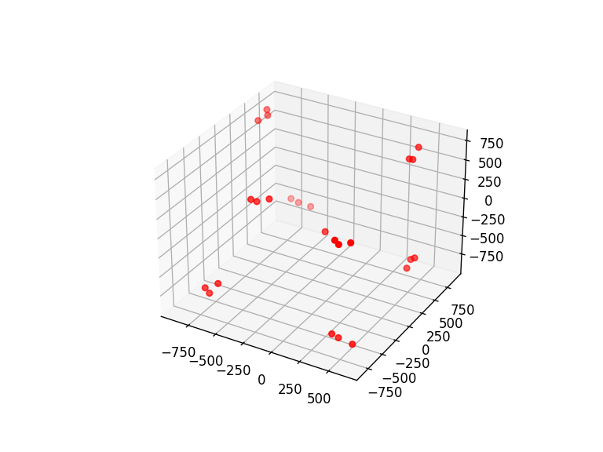

```python
%matplotlib notebook


def plot_3d_data(points, color='red'):
    x = [i[0] for i in points]
    y = [i[1] for i in points]
    z = [i[2] for i in points]
    fig = plt.figure()
    ax = plt.axes(projection='3d')
    ax.scatter(x, y, z, c=color)


plot_3d_data(scanners[0])
```

## Find the relations between different sets

Once we read the data, we should find the sets which share at least 12 points, as stated in the problem description. To do so, we can compute the pairwise distances among all points in the same set (according to some norm). Then, if two sets share at least 66 such distances, it means there are at least 12 points in common between them (since the number of pairwise distances between 12 points is 66, i.e., 12 choose 2). Note that I'm using python sets, which could give wrong results. Indeed, if more than 2 points are at the same distance (for example (0,0,0), (1,1,1), (2,2,2)), only one distance would be counted, and we would potentially miss some related sets (if this causes the shared distances to be less than 66). Neverthless, this is easy to fix, altough I didn't do it and got the right answer anyway!

```python
from scipy.spatial.distance import pdist
from itertools import combinations


couples = []
for cloud_1, cloud_2 in combinations(range(len(scanners)), 2):
    dist_1 = pdist(scanners[cloud_1])
    dist_2 = pdist(scanners[cloud_2])
    shared_distances = set(dist_1) & set(dist_2)
    if len(shared_distances) >= 66:
        couples.append((cloud_1, cloud_2))
        couples.append((cloud_2, cloud_1))

couples
```

```
[(0, 1), (1, 0), (1, 3), (3, 1), (1, 4), (4, 1), (2, 4), (4, 2)]
```

Once we have all the connected "couples" of sets, we can build a graph. This graph will be used later, to determine the order to visit the sets of points. For example, the sets in the example data give rise to the following graph.

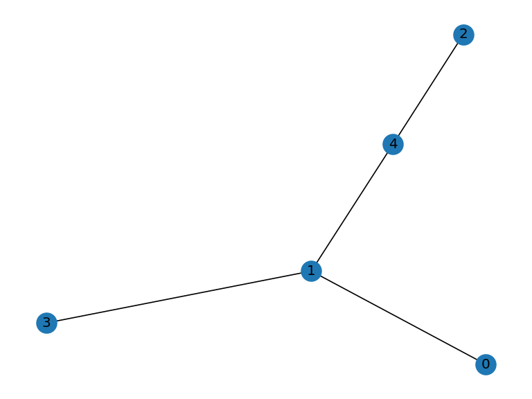

```python
%matplotlib notebook
import networkx as nx


G=nx.Graph()
# Add nodes and edges
for couple in couples:
    G.add_edge(couple[0], couple[1])

nx.draw(G, with_labels=True)
plt.show()
```

```python
def get_right_path(relations, path, visited, couple=(-1, 0)):
    couples = [i for i in relations if i[0] == couple[1]]
    for new_couple in couples:
        if new_couple[1] not in visited and new_couple != couple[::-1]:
            path.append(new_couple)
            visited.add(new_couple[1])
            # recursively find next scanners
            get_right_path(relations, path, visited, couple=new_couple)


path = []
vis = set()
get_right_path(couples, path, vis)
```

```python
[0] + [i[1] for i in path]
```

```
[0, 1, 3, 4, 2]
```

## Find the affine transformation

Up to this point, we didn't describe how to translate a coordinate system to another one given that 2 sets share at least 12 points. We are going to do it next. However, first we need to describe how we identify common points between two sets which share at least 12 points.

```python
from scipy.spatial.distance import squareform
from collections import defaultdict, Counter
from itertools import product



def find_shared_points(points_1, points_2):
    pairwise_dist_1 = pdist(points_1, 'sqeuclidean')
    pairwise_dist_2 = pdist(points_2, 'sqeuclidean')
    shared_distances = set(pairwise_dist_1) & set(pairwise_dist_2)
    if len(shared_distances) < 66:
        raise ValueError("At least 12 points are required!")
    dist_1 = squareform(pairwise_dist_1)
    dist_1[np.tril_indices(len(dist_1))] = 0
    dist_2 = squareform(pairwise_dist_2)
    dist_2[np.tril_indices(len(dist_2))] = 0
    graph_dict = defaultdict(Counter)
    for dist in shared_distances:
        first_group = np.where(dist == dist_1)
        second_group = np.where(dist == dist_2)

        for node1 in first_group:
            for node2 in second_group:
                try:
                    graph_dict[node1.item()][node2.item()] += 1
                except ValueError:
                    for couple in product(node1, node2):
                        graph_dict[couple[0]][couple[1]] += 1
    graph_dict = {
        node: graph_dict[node].most_common(1)[0][0]
        for node in graph_dict.keys()
        if graph_dict[node].most_common(1)[0][1] >= 11
    }
    return graph_dict



find_shared_points(scanners[0], scanners[1])
for key, value in find_shared_points(scanners[0], scanners[1]).items():
    print(scanners[0][key], scanners[1][value])
```

```
[ 528 -643  409] [-460  603 -452]
[-485 -357  347] [ 553  889 -390]
[-661 -816 -575] [729 430 532]
[-345 -311  381] [ 413  935 -424]
[-618 -824 -621] [686 422 578]
[ 404 -588 -901] [-336  658  858]
[ 459 -707  401] [-391  539 -444]
[ 544 -627 -890] [-476  619  847]
[-447 -329  318] [ 515  917 -361]
[ 423 -701  434] [-355  545 -477]
[ 390 -675 -793] [-322  571  750]
[-537 -823 -458] [605 423 415]
```

Here comes the interesting part! Once we have the shared points, we can actually solve the problem. At this point, we have to find the affine transformation which transforms one point cloud to the other. This transformation is given by a rotation matrix and a translation vector. We can actually focus on the rotation matrix, as the translation vector is easy to recover once the points are "aligned".

The problem of finding the rotation matrix can be formalized as an optimization problem. First, we center the point clouds by subtracting them their centroids, i.e., their mean vectors. Then we want to minimize (with respect to the rotation matrix) the sum of the distances between every couple of points. To solve the optimization problem, we can use any optimization algorithm, such as SGD and so on..

```python
import torch
from optimal_pytorch.coin_betting.torch import Cocob



def loss_f(x1, x2, model):
    return torch.linalg.norm(x1 - x2 @ model, axis=1).sum() / len(x1)


def optimize(cloud_1, cloud_2):
    centered_cloud_1 = cloud_1 - cloud_1.mean(axis=0)
    centered_cloud_2 = cloud_2 - cloud_2.mean(axis=0)
    centered_cloud_1 = torch.tensor(centered_cloud_1).float()
    centered_cloud_2 = torch.tensor(centered_cloud_2).float()

    history = [centered_cloud_1, centered_cloud_2]

    model = torch.eye(3, requires_grad=True)
    # optimizer = torch.optim.SGD([model], lr=1e-4)
    optimizer = Cocob([model])
    iterations = 10000
    cum_loss = 0
    for step in range(iterations):
        optimizer.zero_grad()
        loss = loss_f(centered_cloud_1, centered_cloud_2, model)
        loss.backward()
        optimizer.step()
        cum_loss += loss.item()
        converged = torch.all(torch.isclose(centered_cloud_1, centered_cloud_2 @ torch.round(model.detach())))
        history.append(centered_cloud_2 @ model)
        if converged:
            break

    if not converged:
        raise ValueError(
            f"Method has not converged!\n"
            f"Rotation matrix:\n"
            f"{torch.round(model.detach())}\n"
            f"Loss at step {step}: {loss.item()}"
        )
    rot_mat = np.rint(model.detach().numpy()).astype(int)
    transl_vec = cloud_1[0] - cloud_2[0] @ rot_mat
    return rot_mat, transl_vec, step, history



def find_affine_transf(points_1, points_2):
    # retrieve shared points between point clouds
    graph_dict = find_shared_points(points_1, points_2)
    # retrieve affine transformation
    first = points_1[list(graph_dict.keys())]
    second = points_2[list(graph_dict.values())]
    rot_mat, transl_vec, steps, history = optimize(first, second)
    return rot_mat, transl_vec, steps, history



def solve():
    transl_vectors = []
    for couple in path:
        first, second = couple
        rot_mat, transl_vec, iterations, _ = find_affine_transf(point_clouds[first], point_clouds[second])
        point_clouds[second] = point_clouds[second] @ rot_mat + transl_vec
        transl_vectors.append(transl_vec)
```

```python
_, _, _, data = find_affine_transf(scanners[0], scanners[1])
len(data)
```

```
26
```

```python
data = np.array([i.detach().numpy() for i in data])
```

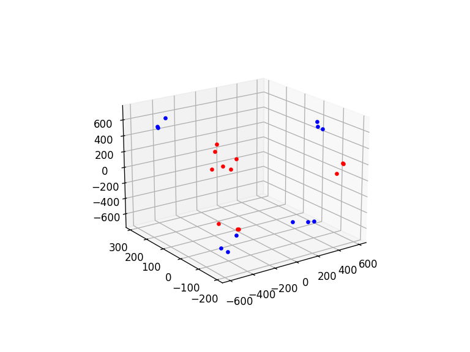

[video not shown]

```python
def update3(i, X, Y, Z, cloud1, cloud2):
    cloud2[0].set_data(X[i], Y[i])
    cloud2[0].set_3d_properties(Z[i])
    return cloud1, cloud2


fig = plt.figure()
ax = fig.add_subplot(111, projection='3d')
cloud_1 = ax.plot(xs[0], ys[0], zs[0], "o", color='blue', markersize=3)
cloud_2 = ax.plot([], [], [], "o", color='red', markersize=3)

# ax limits
x_max = max(xs.flatten())
x_min = min(xs.flatten())
y_max = max(ys.flatten())
y_min = min(ys.flatten())
z_max = max(zs.flatten())
z_min = min(zs.flatten())
ax.set_xlim(x_min - 10, x_max + 10)
ax.set_ylim(y_min - 10, y_max + 10)
ax.set_zlim(z_min - 10, z_max + 10)

ani = animation.FuncAnimation(
    fig,
    update3,
    frames=len(data) - 1,
    fargs=(xs, ys, zs, cloud_1, cloud_2),
    interval=100,
    blit=True,
    repeat=True,
)

HTML(ani.to_html5_video())
# ani.save('rotation.gif', writer='imagemagick', fps=200)
```

I've got to learn that this is a particular case of a more general problem, known as point-set registration.